# Startup Funds Investigation

Susan VanderPlas

June 10, 2015

# Introduction

The following information was taken from meeting notes (meetings on 6/4/2015 and 5/20/2015)

## Goals for the project:

1. Examine trends (or lack thereof) in startup funding over time
2. Examine return on investment for startup funding
   - Publications
   - Proposals submitted
   - Grants received
   - Tenure

## Data:

1. Spreadsheets from the Office of the Vice President for Research
   - Name, Department, College, Salary, Start Date
   - Startup package allocation (by category)
   - Source of startup funding
2. Database from Office of Sponsored Programs Administration (2 databases, 2005-2010 and 2010-2015. Early database will be messier)
   - Grants received (by month, as well as total award $$)
   - Proposals submitted
3. Additional information
   - Publications (from scraping Google Scholar)
   - Where individuals came from (public/private institution, small/large)

## Other factors:

- 2003-2008 was a competitive hiring season (may have larger startup packages as a result)
- 2008 Crash and budget freeze at the state level
- American Recovery and Reinvestment Act (2009) with increased funding levels
- 2012 slowdown in research funding (may need to compare to NSF/NIH/USDA/DOD/DOE/Ames Lab funding levels)

# Analysis

## Office of the Vice President for Research Data

### Total Startup Package Cost

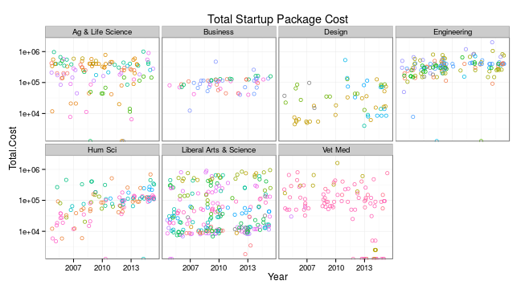

### Computing Expenses

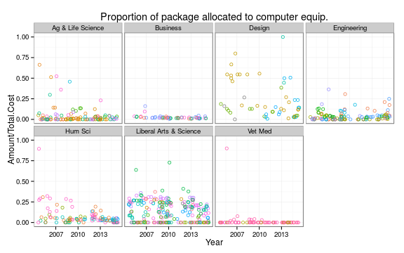

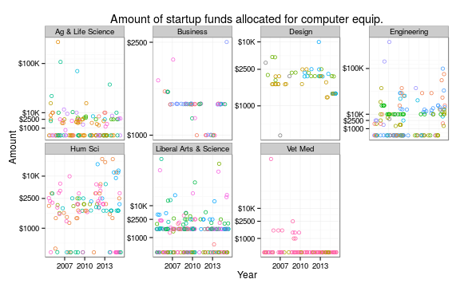

In Ag & Life Science, I suspect the computer allocation has decreased due to Moore's law (it's cheaper to get computers that can process genetic data now than it was in 2005). Engineering allocations seem to be somewhat department-related (clustering of green and blue values, in particular). The business school seems remarkably standardized - the amount decreased in 2011-2013, but otherwise has been at approximately the same level (with extremely low variance).

### Lab Space/Equipment Expenses

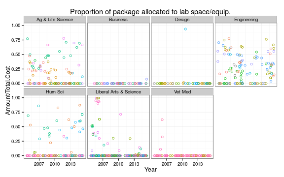

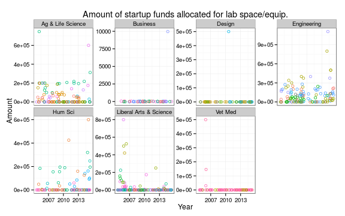

Lab space and lab equipment are obviously only relevant for some colleges. The proportion and raw amount of funding for lab space and equipment in LAS has decreased, while the amount of funding in engineering and human sciences has increased (though the proportion of the funding package has stayed reasonably consistent).

### Graduate Assistant Expenses

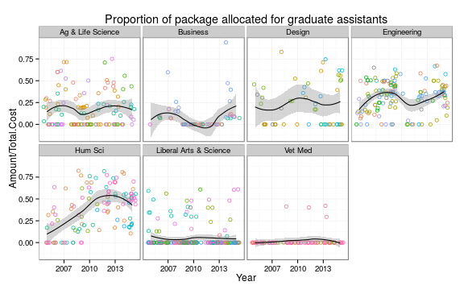

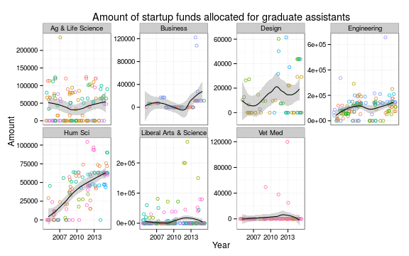

The recession seems to have hit graduate student support fairly hard (relative to other expenses). Looking at the gross amount of funding allocated for graduate students, we see that startup packages in engineering and human sciences include more support for graduate students than in the past (this is particularly dramatic in human sciences, though the amount of funding is still overall lower than in engineering). In the other colleges, the amount of support for graduate students has stayed relatively consistent over the past 10 years.

### Summer Support

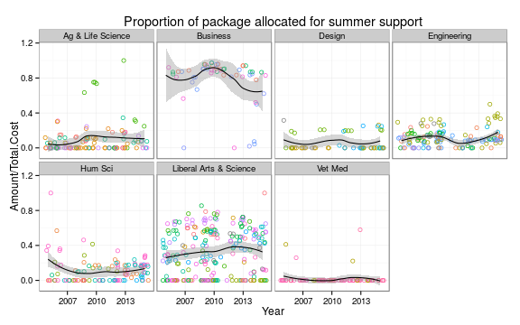

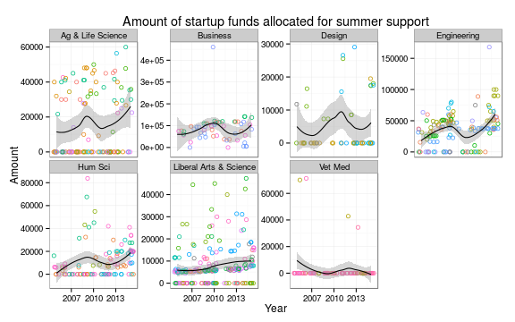

Summer funding seems to be fairly common in some areas (business, some of LAS) and almost unheard of in others (design, vet med).

### Research Support

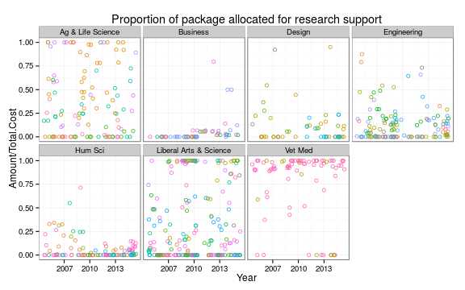

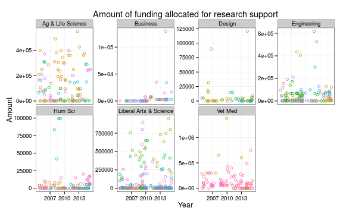

### Moving Expenses

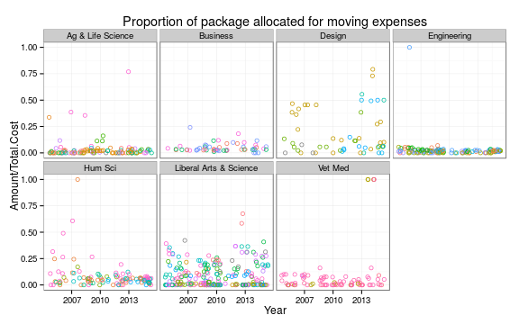

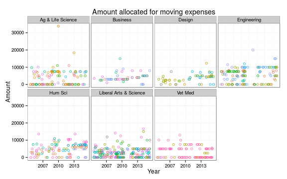

Moving expenses amounts seem to be reasonably consistent across colleges. The business college seems to once again have a standard package that may change year to year with occasional negotiation. The same may be true of the vet med college.

## Office of Sponsored Programs Administration Data

Datasets from OSPA contain information on proposals and awards from 2005-2010 and 2010-2015 (4 total databases).

### Proposals

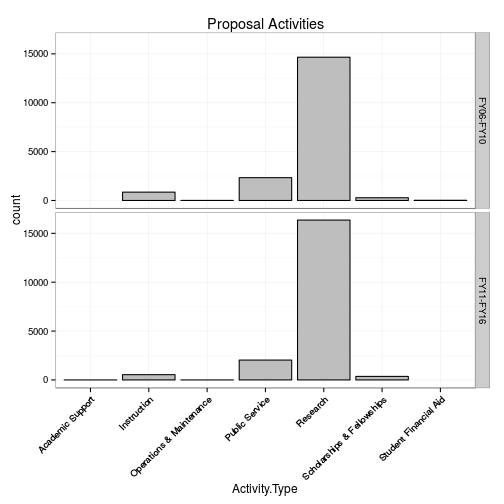

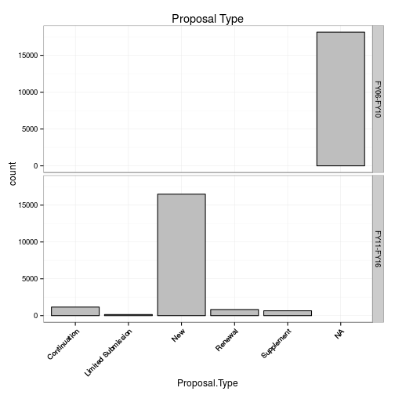

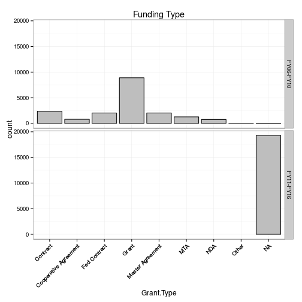

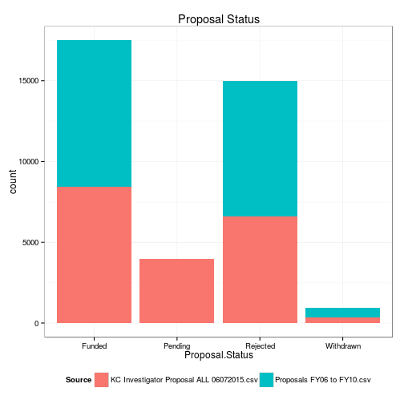

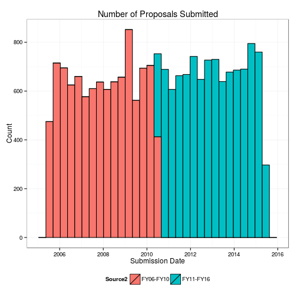

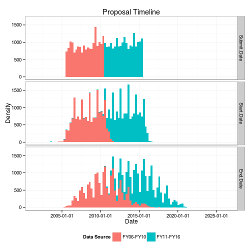

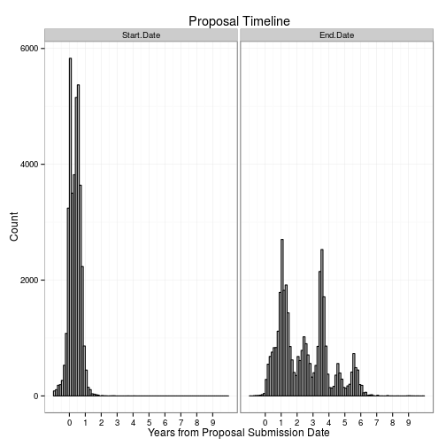

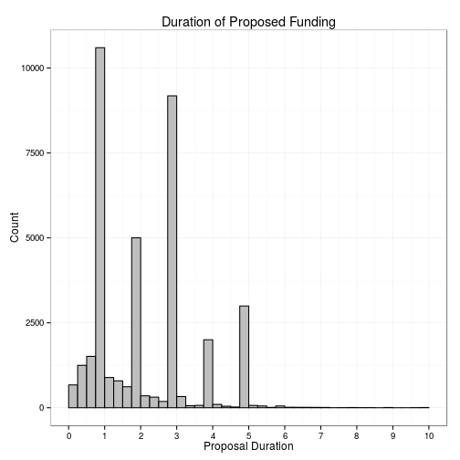

### Awards

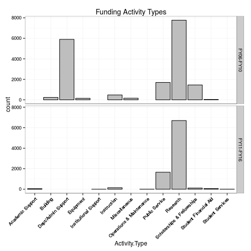

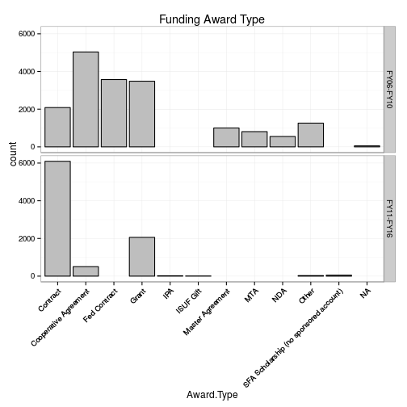

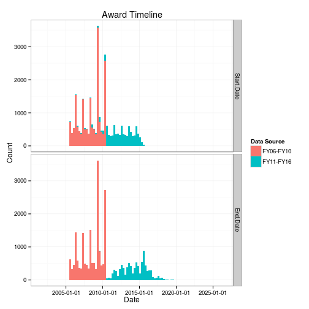

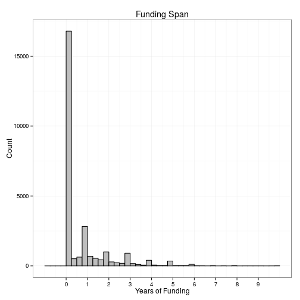

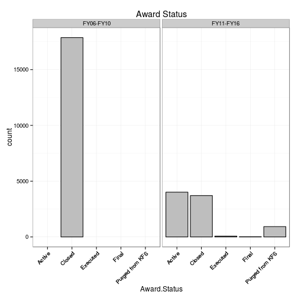

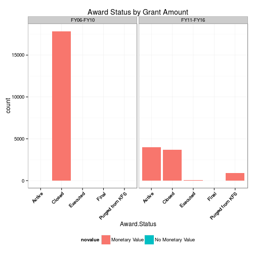

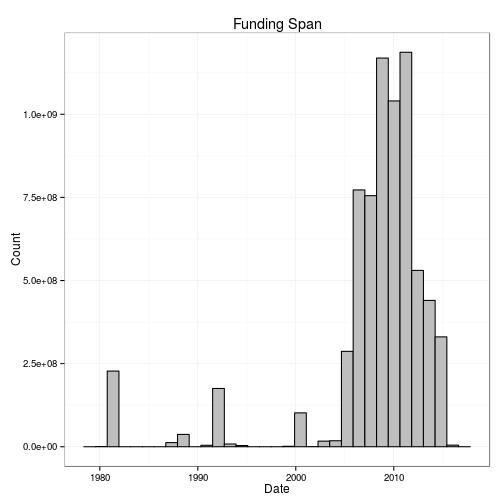

# Merged Data

We'll begin by looking at the timeline - how many years at ISU are necessary before grant applications are successful? We split this by college and faculty rank (as we'd expect that full professors who are hired should be able to command grant money sooner than new faculty). Subsequent graphs show data from hired professors (i.e. not adjuncts, affiliates, lecturers, or clinicians).

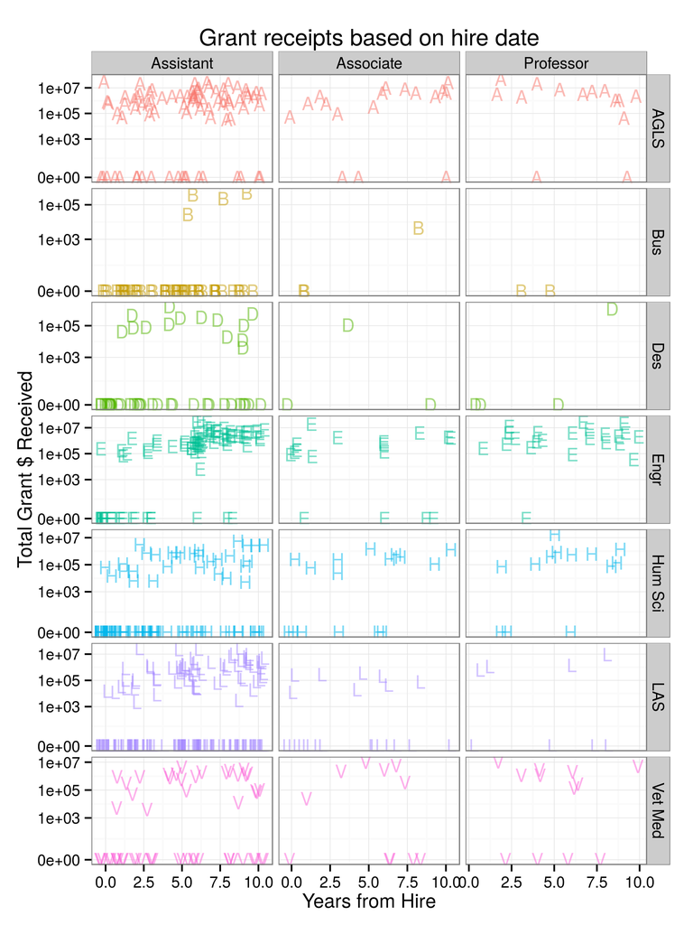

In order to examine the effect of startup funding on grant receipts over a career of variable duration, we will examine the distribution of startup funding by college, categorizing startup costs by the quartile (calculated for the hire's college). Below, vertical lines mark these quantiles

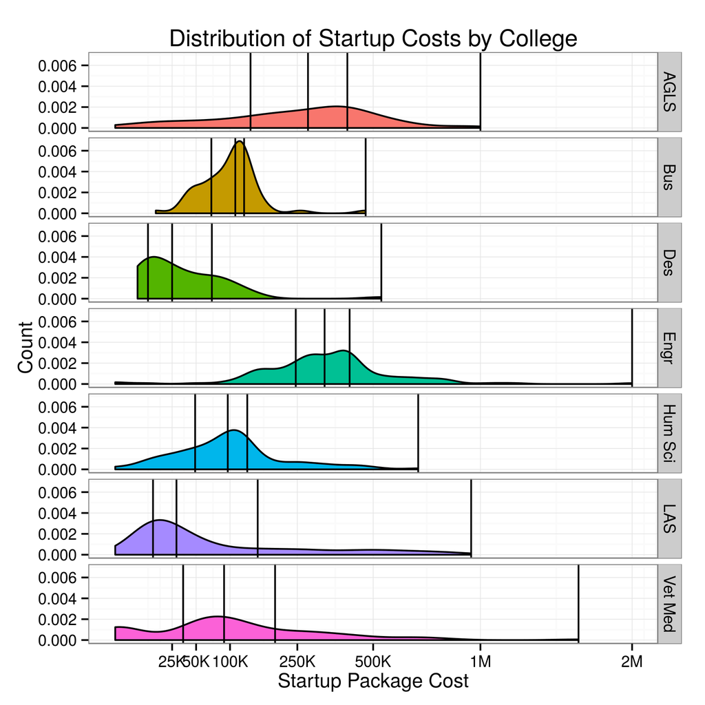

Using these quantile calculations, we then can examine total grants received as explained by years since hired.

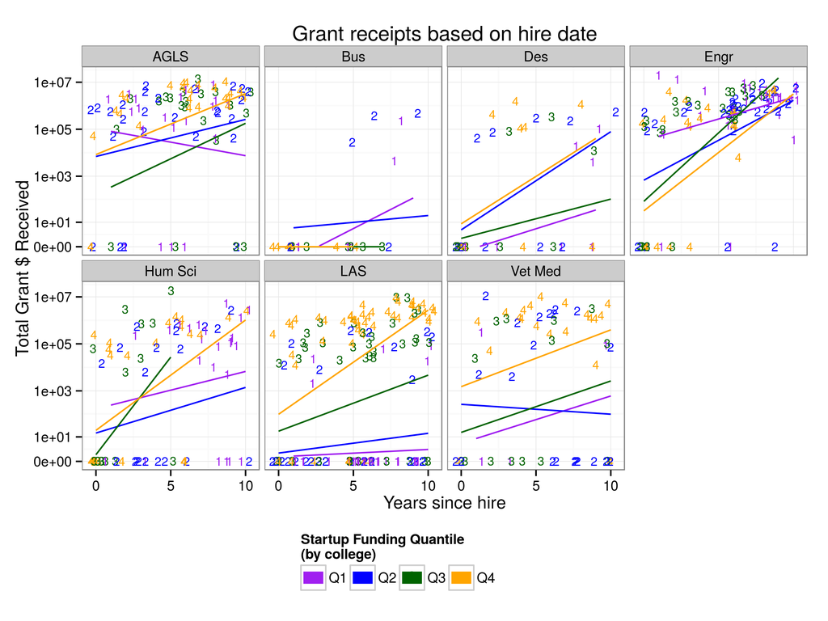

It is important to note several caveats at this point: first, hires are not separated out by faculty rank or position, so hires whose primary responsibilities include administrative work may command large startup packages but bring in relatively little grant funding. Additionally, different colleges have different funding structures: LAS, for instance, may need to provide lab startup funding for science based departments, but would not have to provide this funding for new hires in English or History. Finally, the x-axis shows years since hire, which does not necessarily translate to years at ISU (faculty hired in 2005 may have left in 2011 after receiving tenure, for example).

Linear regression lines are provided here as (extremely) rough approximations; it may be useful to examine the right-most endpoint (rather than the entire line) as a prediction of total grant money received after 10 years at ISU.

With these caveats in mind,

- Startup funding in LAS is correlated with later grant funding; this is likely explained by departmental startup funding (and grant funding) norms.
- Startup funding in engineering is largely not predictive of grant receipts; after 10 years, hires with small startup packages receive approximately the same grant funding as hires with large startup packages.
- Startup funding in Human Sciences is correlated with later grant funding- this may again be a departmental norm situation (psychologists may require lab space and compete for NSF/NIH grants, where professors in the education department require fewer financial resources when hired and receive fewer grants.)
- Grants are relatively rare in the business college.

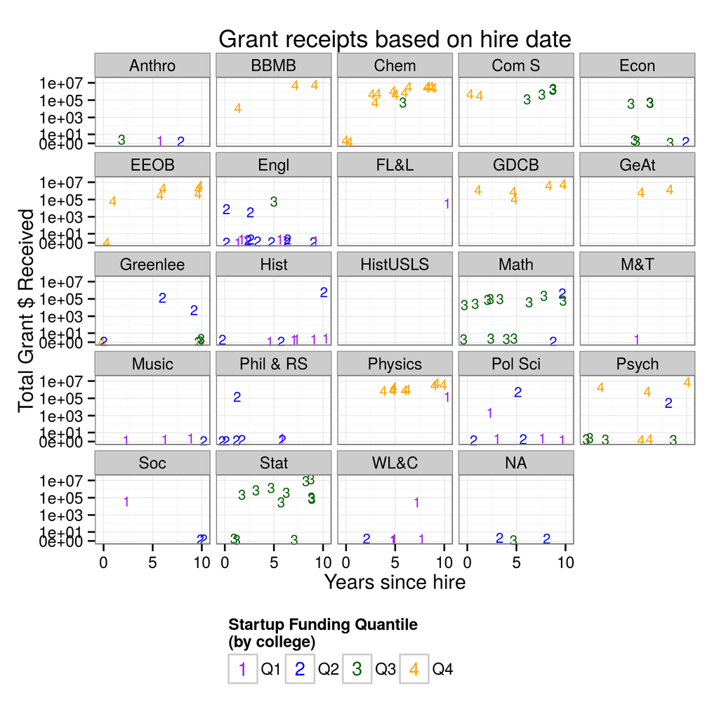

Styled with knitrBootstrap